# plot.matrix

## `NA` handling

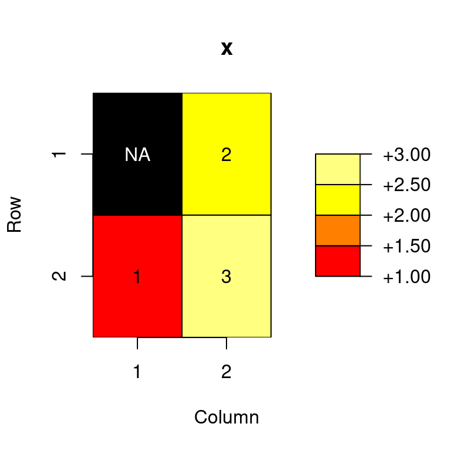

```r
x <- matrix(c(NA, 1, 2, 3), ncol=2)
par(mar=c(5.1, 4.1, 4.1, 4.1))   # adapt margins
plot(x, na.col='black', fmt.cell='%.0f')
```

You may enforce with `na.print` no printing of `NA`s or using a replacement text

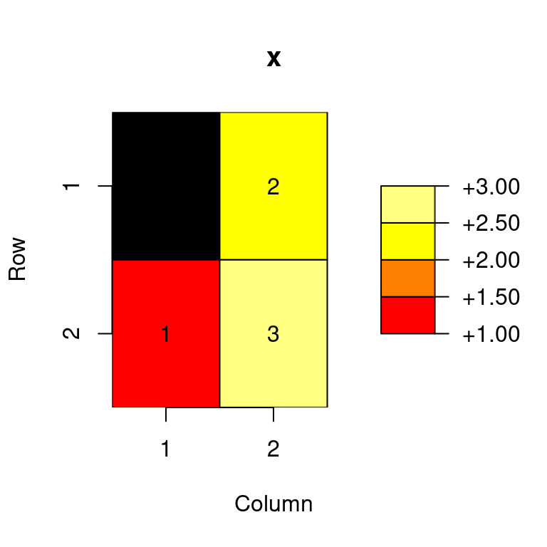

```r
x <- matrix(c(NA, 1, 2, 3), ncol=2)
par(mar=c(5.1, 4.1, 4.1, 4.1))   # adapt margins
plot(x, na.col='black', fmt.cell='%.0f', na.print=FALSE)
```

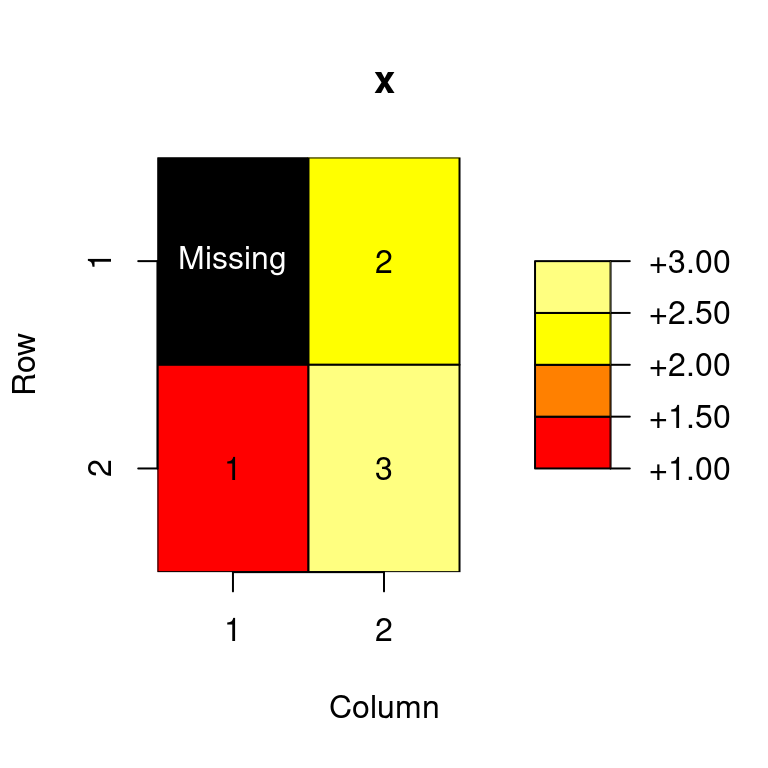

```r
plot(x, na.col='black', fmt.cell='%.0f', na.print='Missing')
```

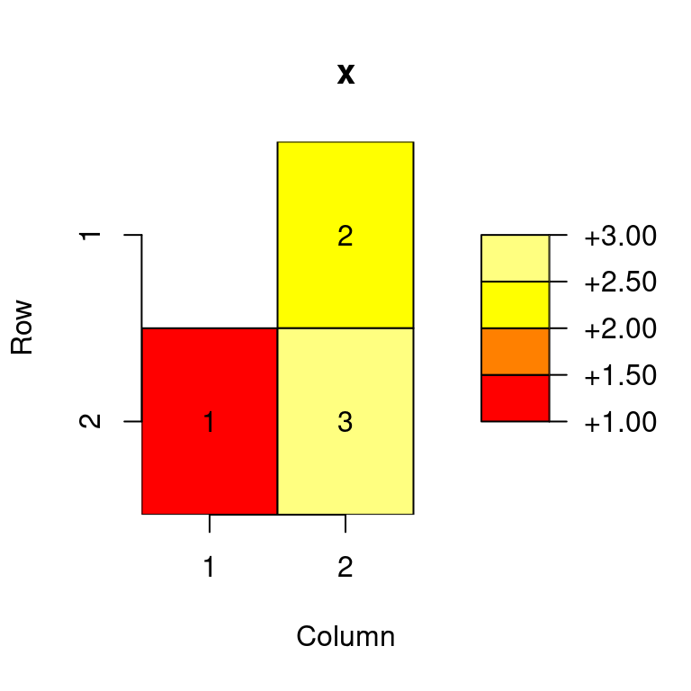

```r
x <- matrix(c(NA, 1, 2, 3), ncol=2)
par(mar=c(5.1, 4.1, 4.1, 4.1))   # adapt margins
plot(x, fmt.cell='%.0f', na.cell=FALSE)
```

## Automatic text color adjustment

It may happen that the text color and cell background color are [too near](https://en.wikipedia.org/wiki/Color_difference#Euclidean) which means you can not read the text anymore in a cell

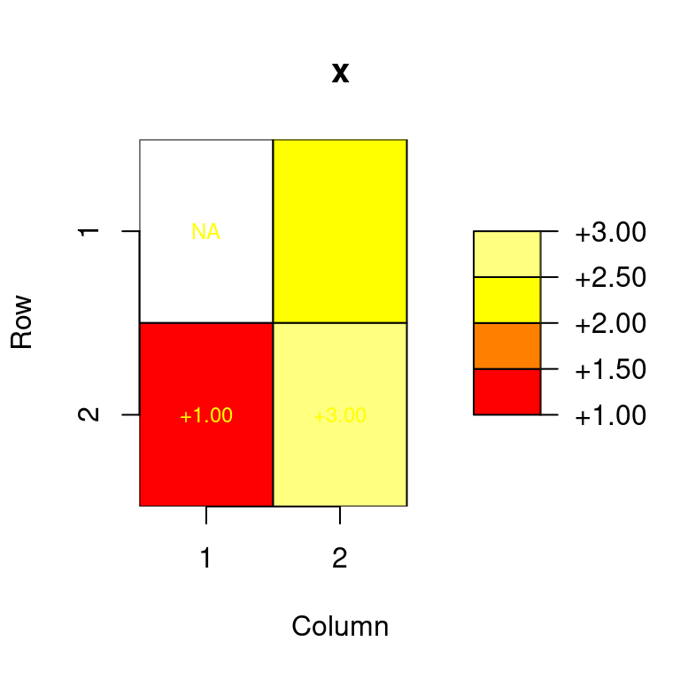

```r
par(mar=c(5.1, 4.1, 4.1, 4.1))   # adapt margins
# Never replace text color by black or white
plot(x, digits=2, text.cell=list(col="yellow", cex=0.75), max.col=-1)
```

By default the text color is replaced by black or white (which is [farer away](https://en.wikipedia.org/wiki/Color_difference#Euclidean))

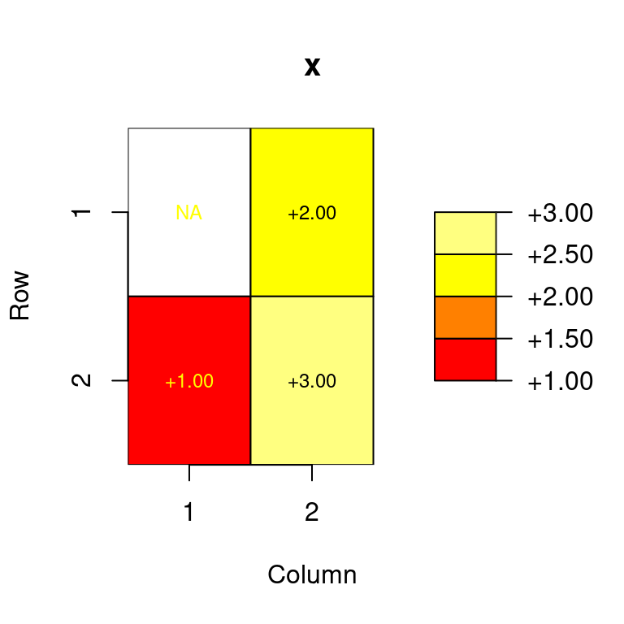

```r
par(mar=c(5.1, 4.1, 4.1, 4.1))   # adapt margins
plot(x, digits=2, text.cell=list(col="yellow", cex=0.75))
```

Just replace text color if colors are nearer then the default `max.col=70`

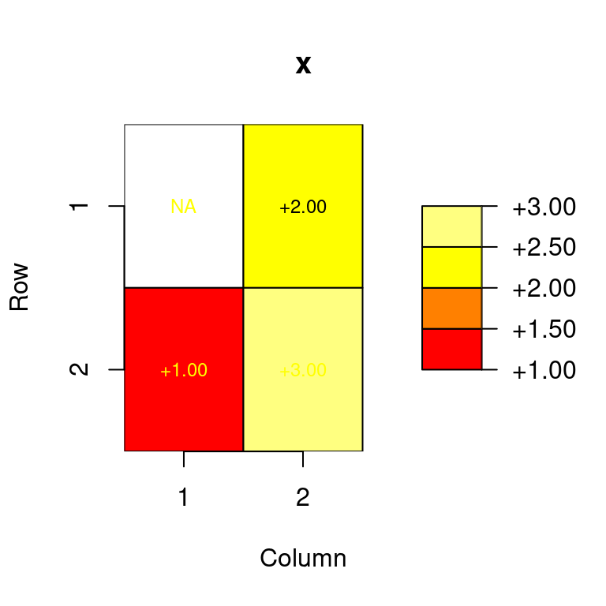

```r
par(mar=c(5.1, 4.1, 4.1, 4.1))   # adapt margins
# In fewer cells the text color will be replaced by black
plot(x, digits=2, text.cell=list(col="yellow", cex=0.75), max.col=35)
```

or farer away then the default

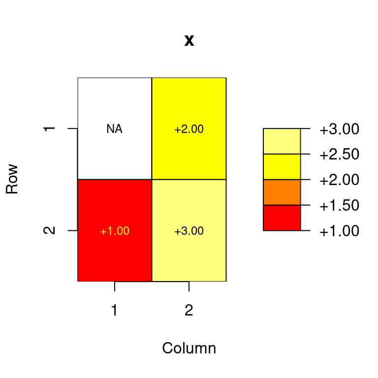

```r
par(mar=c(5.1, 4.1, 4.1, 4.1))   # adapt margins
# In more cells the text color will be replaced by black
plot(x, digits=2, text.cell=list(col="yellow", cex=0.75), max.col=140)
```

Of course, the best solution is to choose a good color scheme and a good text color ;)

## Information about drawn elements

The `plot` command returns invisibly a list of the elements drawn, a bit like `hist`. A `NULL` entry means the element has not been drawn. The data may be useful for adding own elements in the graphic.

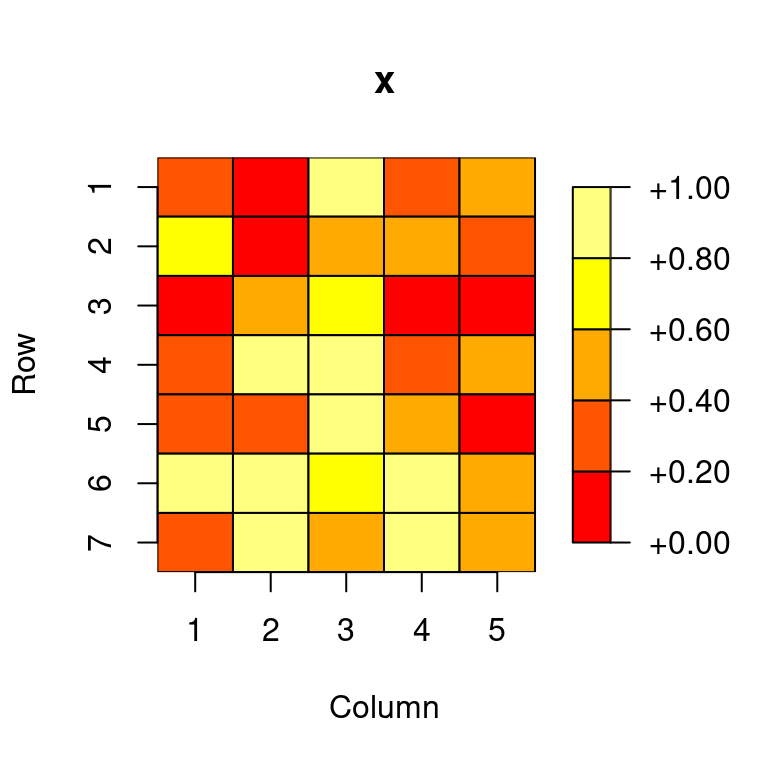

```r
# numeric matrix
x <- matrix(runif(35), ncol=5) # create a numeric matrix object
par(mar=c(5.1, 4.1, 4.1, 4.1)) # adapt margins
res <- plot(x)
```

Available are the parameters for

- `cell.polygon`, `cell.text`: the polygon and the text used to draw a matrix element,
- `key.polygon`, `key.axis`: the polygon and the axis used to draw a key element, and
- `plot`, `axis.col`, `axis.row`: the basic plot and the axes drawn.

```r
#####
names(res)
```

```
#> [1] "plot"         "cell.polygon" "cell.text"    "axis.col"     "axis.row"
#> [6] "key.axis"     "key.polygon"
```

```r
# parameters of polygon which was used to draw x[3,4]
res$cell.polygon[[3,4]]
```

```
#> $y
#> [1] 4.5 5.5 5.5 4.5
#>
#> $x
#> [1] 3.5 3.5 4.5 4.5
#>
#> $col
#> [1] "#FF0000"
```

```r
#####
# parameters of text which was used for x[3,4]
res$cell.text[[3,4]]  # NULL since no text was drawn
```

```r
#####
# parameters of polygon which was used to draw the second key element
res$key.polygon[[2]]
```

```
#> $x
#> [1] 6.0 6.0 6.5 6.5
#>
#> $y
#> [1] 2.2 3.4 3.4 2.2
#>
#> $col
#> [1] "#FF5500"
```

#### Example: Add shading lines

[figure not shown]

```r
x <- matrix(runif(35), ncol=5) # create a numeric matrix object
par(mar=c(5.1, 4.1, 4.1, 4.1)) # adapt margins
res <- plot(x)

for (i in 1:length(res$cell.polygon)) {
  args <- res$cell.polygon[[i]]
  args$col     <- NA       # use no color
  args$density <- 20*x[i]  # density depends on matrix entries
  args$angle   <- 45
  do.call("polygon", args)
}
```

#### Example: Adding images

Please note that the PNGs have a transparent background. It depends on the graphic device how the transparency is taken into account.

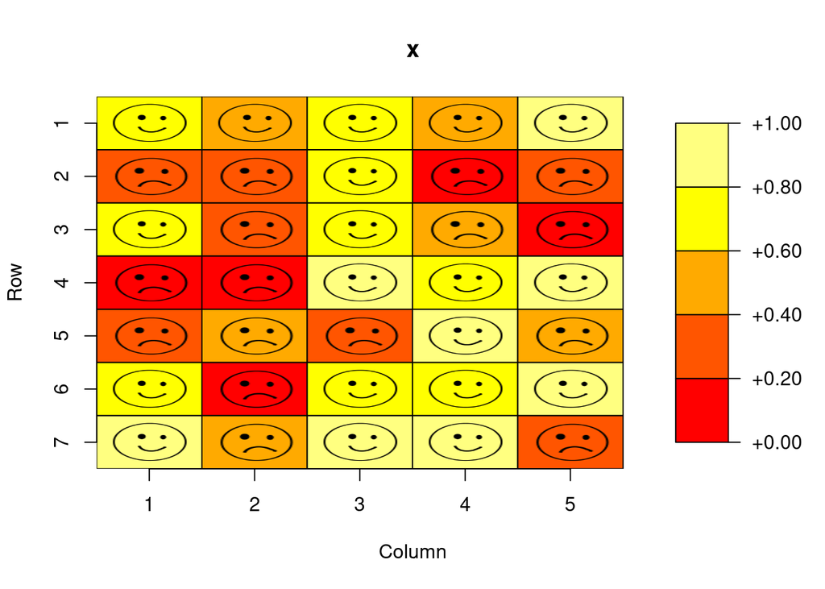

```r
x <- matrix(runif(35), ncol=5) # create a numeric matrix object
par(mar=c(5.1, 4.1, 4.1, 4.1)) # adapt margins
res <- plot(x)
#
library("png")
# PNGs are created from wikimedia commons images, CC0 by C. Koltzenburg
# https://commons.wikimedia.org/wiki/File:C.Koltzenburg_-_smiley-yes.xcf
# https://commons.wikimedia.org/wiki/File:C.Koltzenburg_-_smiley_no.xcf
happy <- readPNG(system.file('png', 'happy.png', package="plot.matrix"))
sad   <- readPNG(system.file('png', 'sad.png', package="plot.matrix"))

for (i in 1:length(res$cell.polygon)) {
  args <- res$cell.polygon[[i]]
  if (x[i]>0.5) {
    rasterImage(happy, args$x[1]+0.1, args$y[1]+0.1, args$x[3]-0.1, args$y[2]-0.1)
  } else {
    rasterImage(sad, args$x[1]+0.1, args$y[1]+0.1, args$x[3]-0.1, args$y[2]-0.1)
  }
}
```

# Plotting special matrices

For some special matrices we have special plot routines:

- loadings of a factor analysis or principal component analysis: `plot.loadings`
- correlations: `plot.cor`
- associations: `plot.assoc`
- p values: `plot.pvalue`

All plot routines support the parameters

- `gray` and `grey` for gray scale image
- `reorder` for reordering rows (default: `reorder=TRUE`)

Note that matrix columns are only reordered if the column names are identical to the row names.

## Loadings matrix

In factor or principal component analysis you may want to view the loadings matrix. The S3 function `plot.loadings` allows to create a heatmap with loadings. It differs from plotting a matrix by

- the color key ranges from -1 to 1,
- the breaks are set to `c(-sqrt(c(1, 0.75, 0.5, 0.25, 0.16)), 0, sqrt(c(1, 0.75, 0.5, 0.25, 0.16)))`,
- the matrix rows, corresponding to the variables, are reordered (according to the breaks),
- the matrix entries are printed with two digits after the comma.

A typical threshold in factor analysis is an absolute loading greater equal 0.5; thus a factor “explains” 25% of the variance of a variable. Further thresholds are selected such that they explain 50% and 75% of the variable variance. Sometimes it might be useful to check whether there are loadings a little bit under 0.5, therefore another threshold of 0.4 is added.

All parameters described in **Modifying a plot** can be used in `plot.loadings` as well.

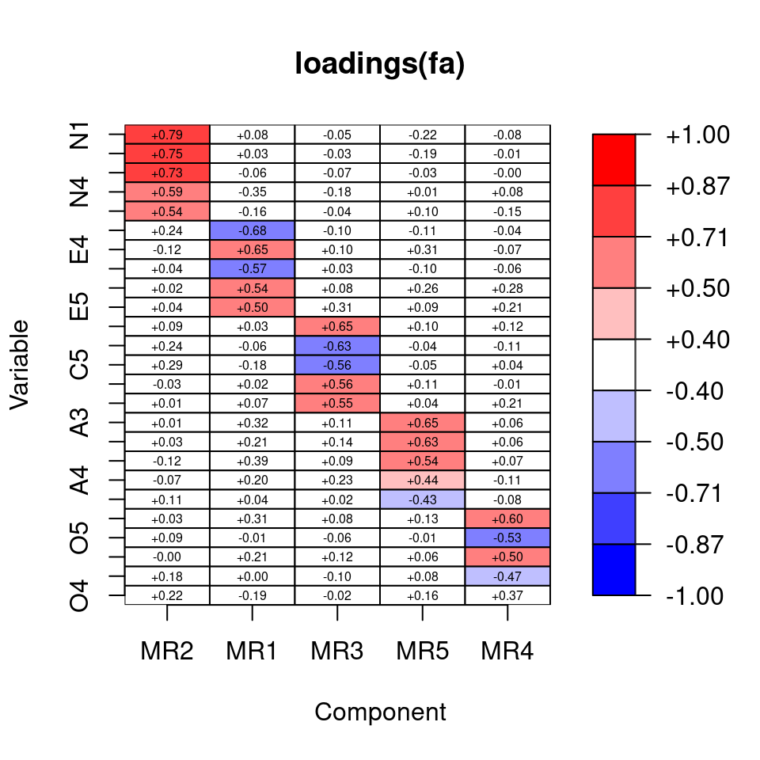

```r
library('plot.matrix')
library('psych')
data(bfi.2)
fa <- fa(bfi.2, 5, rotate="varimax")
par(mar=c(5.1, 4.1, 4.1, 4.1)) # adapt margins
plot(loadings(fa), cex=0.5)
```

### Gray scale

For using a gray color scheme add `gray=TRUE`or `grey=TRUE` to the call

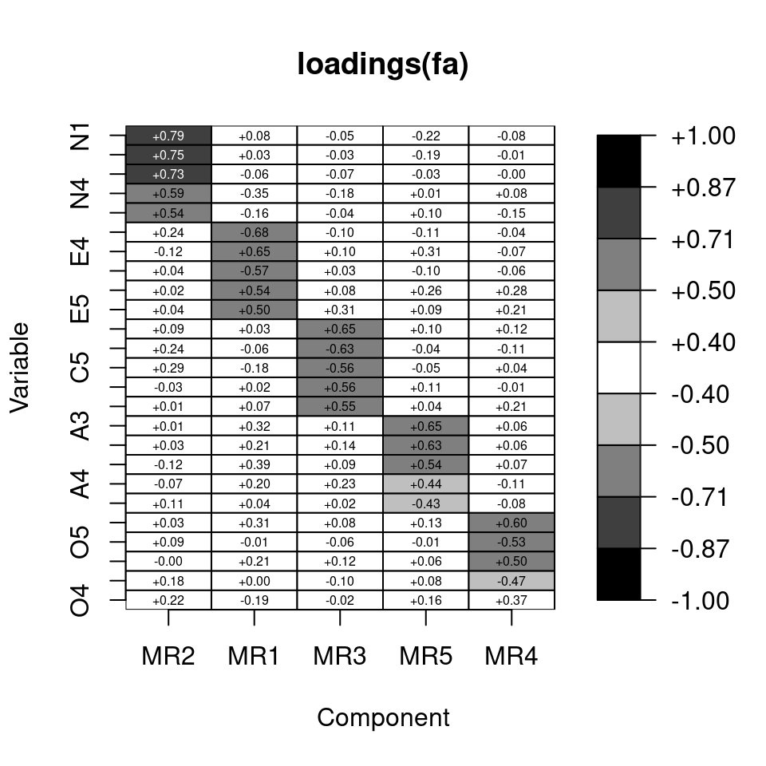

```r
library('plot.matrix')
library('psych')
data(bfi.2)
fa <- fa(bfi.2, 5, rotate="varimax")
par(mar=c(5.1, 4.1, 4.1, 4.1)) # adapt margins
plot(loadings(fa), cex=0.5, gray=TRUE)
```

### No matrix entries

For not printing loading entries use the parameter `digits`:

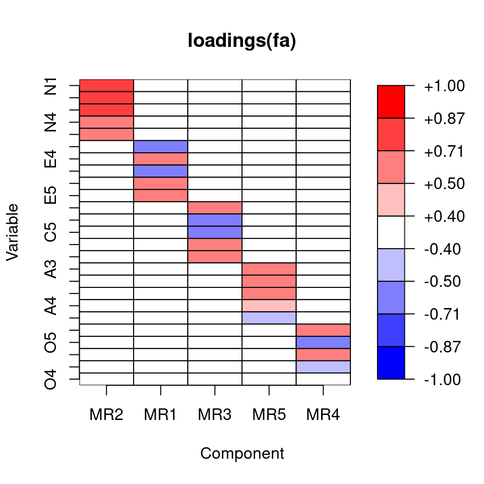

```r
library('plot.matrix')
library('psych')
data(bfi.2)
fa <- fa(bfi.2, 5, rotate="varimax")
par(mar=c(5.1, 4.1, 4.1, 4.1)) # adapt margins
plot(loadings(fa), digits=NA)
```

### No reordering of rows

For not reordering the variables use the parameter `reorder`:

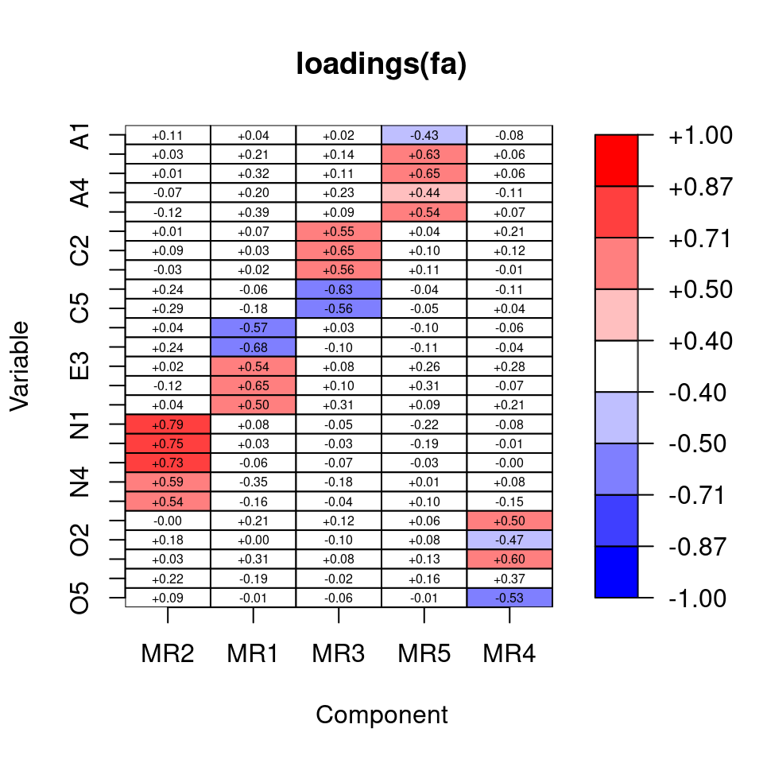

```r
library('plot.matrix')
library('psych')
data(bfi.2)
fa <- fa(bfi.2, 5, rotate="varimax")
par(mar=c(5.1, 4.1, 4.1, 4.1)) # adapt margins
plot(loadings(fa), reorder=FALSE, cex=0.5)
```

## Correlations and associations

The S3 function `plot.cor` and `plot.assoc` allow to create a heatmap with the coefficients. It differs from plotting a matrix by

- the color key ranges from -1 to 1 for correlations and 0 to 1 for associations,
- the breaks are set to reflect the effect sizes given by Cohen
- the matrix rows, corresponding to the variables, are reordered using `dist` and `hclust` with the defaults on the rows,
- the matrix entries are printed with two digits after the comma.

All parameters described in **Modifying a plot** can be used in `plot.assoc` or `plot.cor` as well.

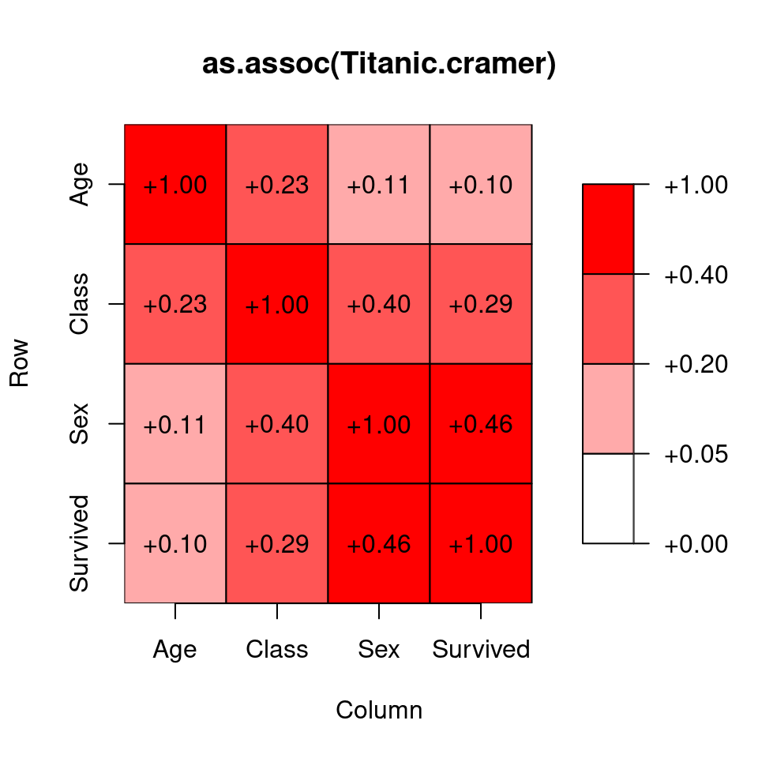

```r
library('plot.matrix')
data(Titanic.cramer)
par(mar=c(5.1, 4.1, 4.1, 4.1)) # adapt margins
plot(as.assoc(Titanic.cramer))
```

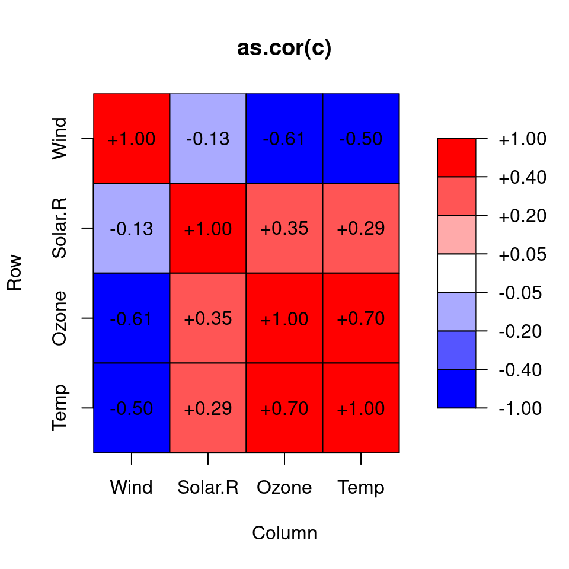

```r
library('plot.matrix')
library('datasets')
c <- cor(airquality[,1:4], use="complete")
par(mar=c(5.1, 4.1, 4.1, 4.1)) # adapt margins
plot(as.cor(c))
```

### Gray scale

For using a gray color scheme add `gray=TRUE`or `grey=TRUE` to the call

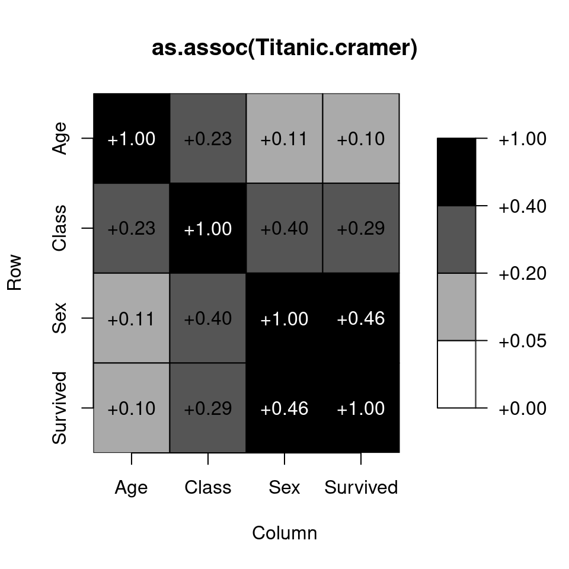

```r
library('plot.matrix')
data(Titanic.cramer)
par(mar=c(5.1, 4.1, 4.1, 4.1)) # adapt margins
plot(as.assoc(Titanic.cramer), gray=TRUE)
```

### No matrix entries

For not printing loading entries use the parameter `digits`:

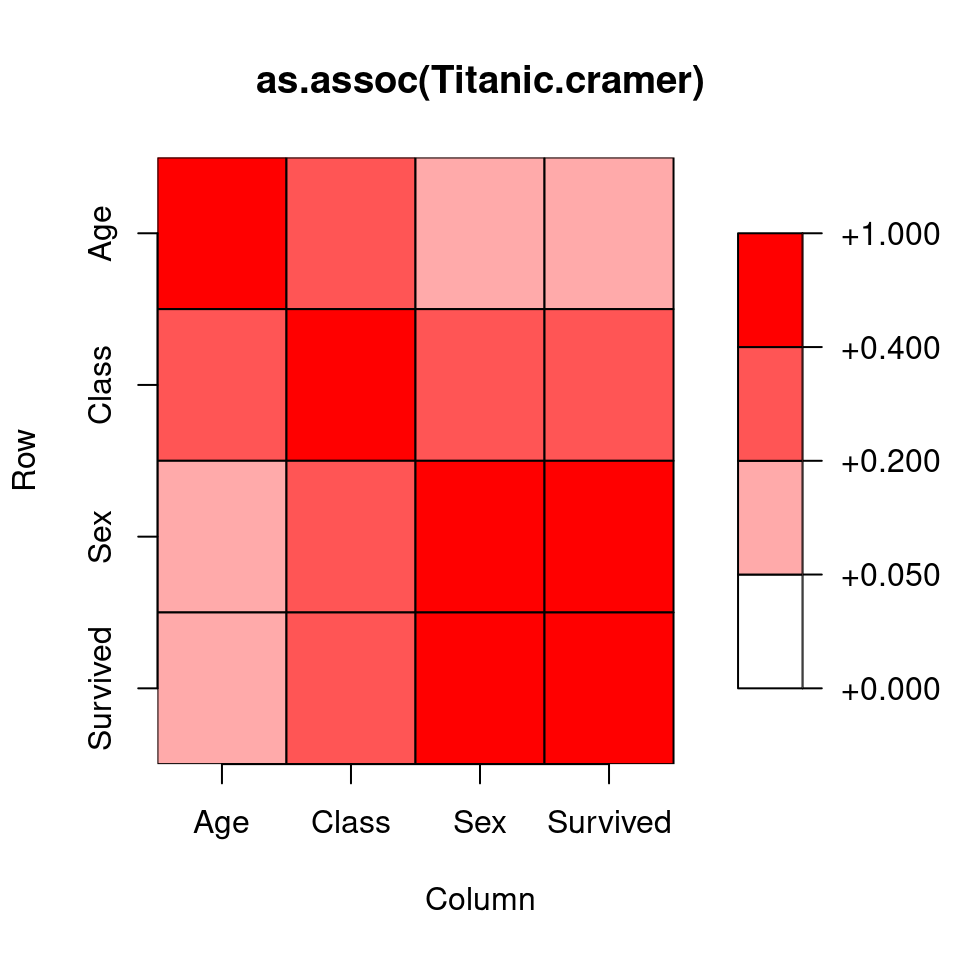

```r
library('plot.matrix')
data(Titanic.cramer)
par(mar=c(5.1, 4.1, 4.1, 4.1)) # adapt margins
plot(as.assoc(Titanic.cramer), digits=NA)
```

### No reordering of rows

For not reordering the variables use the parameter `reorder`:

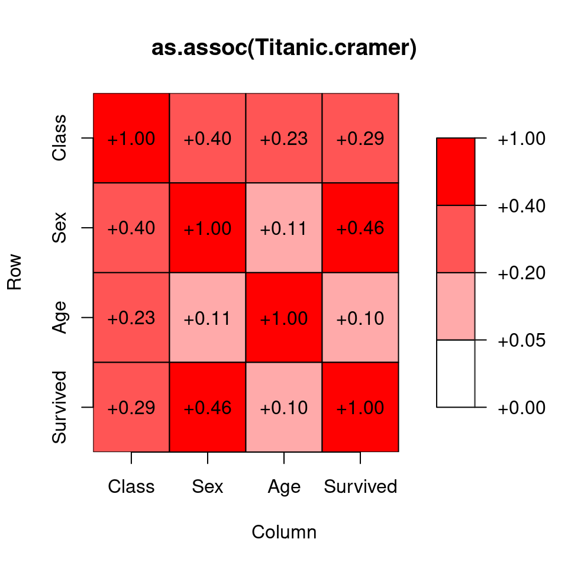

```r
library('plot.matrix')
data(Titanic.cramer)
par(mar=c(5.1, 4.1, 4.1, 4.1)) # adapt margins
plot(as.assoc(Titanic.cramer), reorder=FALSE)
```

## P values

The S3 function `plot.pvalue` allows to create a heatmap from a matrix of p values. It differs from plotting a matrix by

- the color key ranges from 0 to 1
- the breaks are set to 0, 0.1, 0.05, 0.01, 0.001 and 1
- the matrix rows, corresponding to the variables, are reordered using `dist` and `hclust` with the defaults on the rows,
- the matrix entries are printed with three digits after the comma.

All parameters described in **Modifying a plot** can be used in `plot.pvalue` as well.

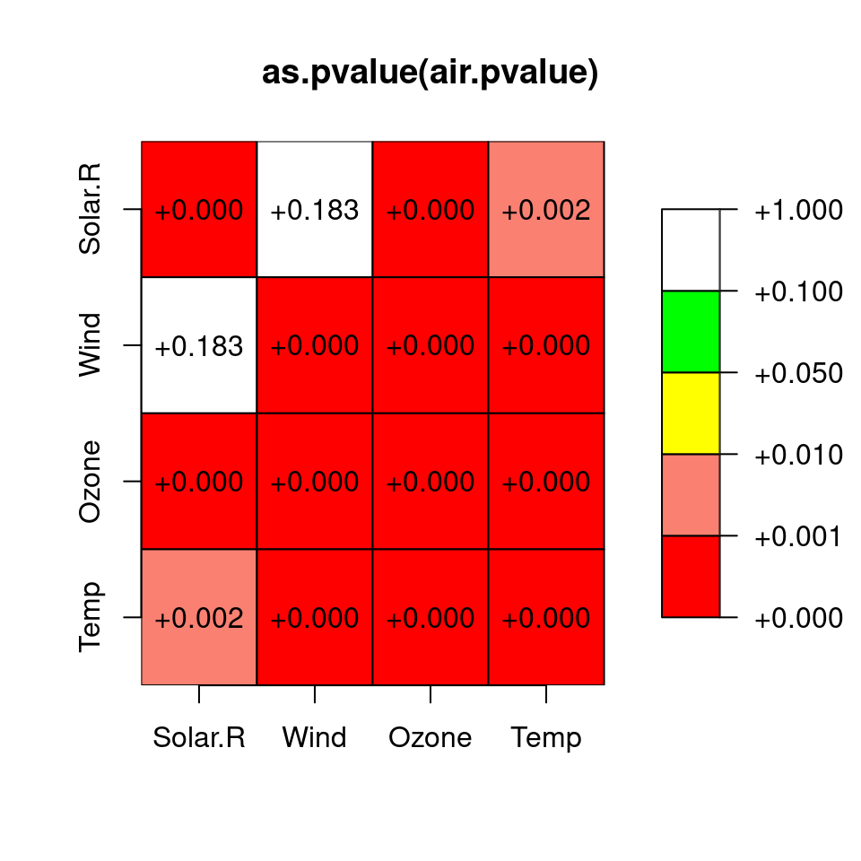

```r
library('plot.matrix')
data(air.pvalue)
par(mar=c(5.1, 4.1, 4.1, 4.1)) # adapt margins
plot(as.pvalue(air.pvalue))
```

### Gray scale

For using a gray color scheme add `gray=TRUE`or `grey=TRUE` to the call

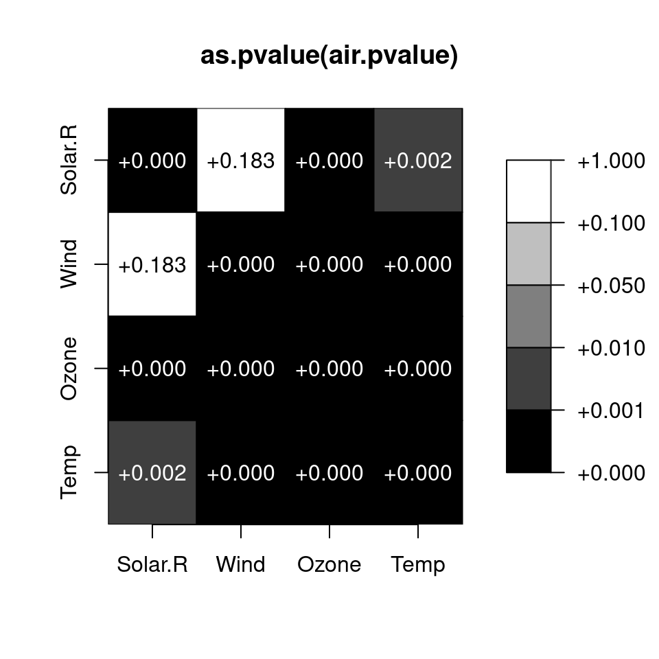

```r
library('plot.matrix')
data(air.pvalue)
par(mar=c(5.1, 4.1, 4.1, 4.1)) # adapt margins
plot(as.pvalue(air.pvalue), gray=TRUE)
```

### No matrix entries

For not printing loading entries use the parameter `digits`:

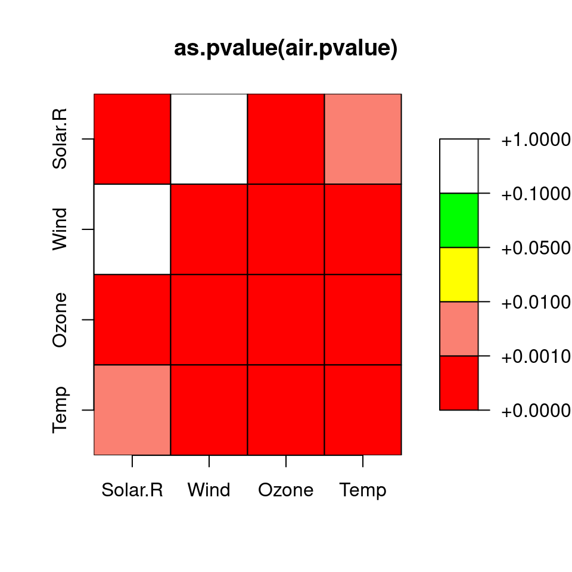

```r
library('plot.matrix')
data(air.pvalue)
par(mar=c(5.1, 4.1, 4.1, 4.1)) # adapt margins
plot(as.pvalue(air.pvalue), digits=NA)
```

### No reordering of rows

For not reordering the variables use the parameter `reorder`:

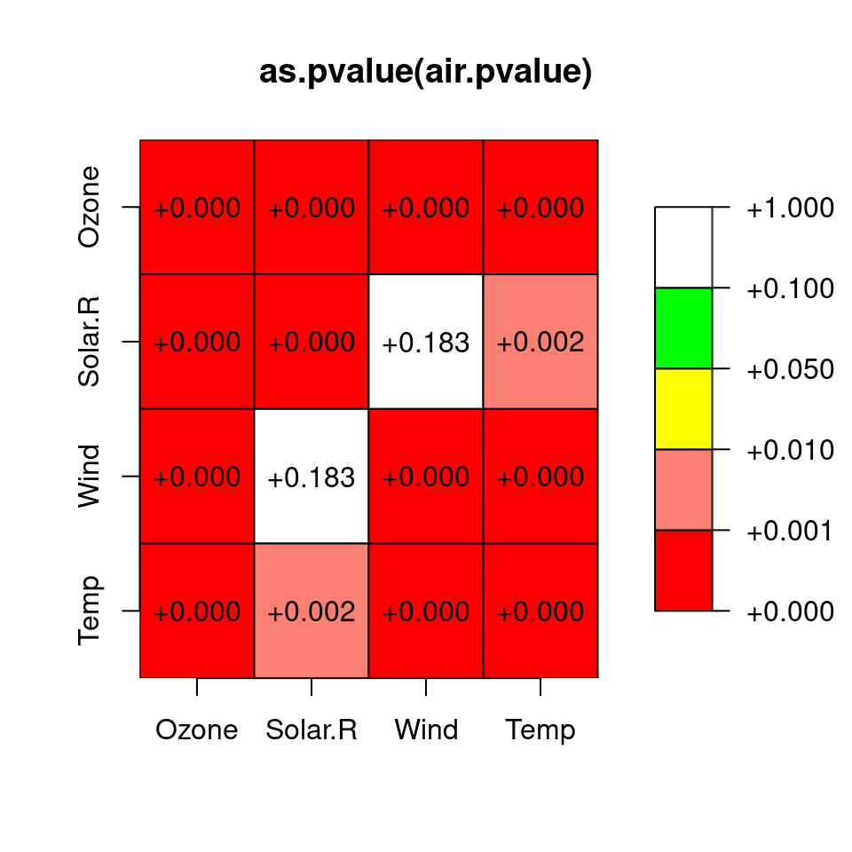

```r
library('plot.matrix')
data(air.pvalue)
par(mar=c(5.1, 4.1, 4.1, 4.1)) # adapt margins
plot(as.pvalue(air.pvalue), reorder=FALSE)
```